# **Chapter 10** Kinematic Chains II: Inverse Kinematics

This chapter describes inverse kinematics (IK), why it is a generally difficult problem, and how it relates to human movement control and human movement measurement.

- What is inverse kinematics (IK)?
- Why are IK calculations difficult?
- IK solution for two-link kinematic chain
- Use of IK in human movement studies
- Summary

# What is inverse kinematics (IK)?

Back to Table of Contents

- Inverse kinematics (IK) refers to the process of calculating internal coordinates from a set of known external coordinates.
- This is the opposite of forward kinematics (FK), which aims to calculate external coordinates given known internal coordinates (*see Fig.1 and the previous chapter*)
- For kinematic chains, the internal coordinates are joint angles, and the external coordinates are usuall the position(s) of external points.
- The external points are often endpoint positions, like in Video 1 below.
- The external points can also be marker positions (like in motion capture).

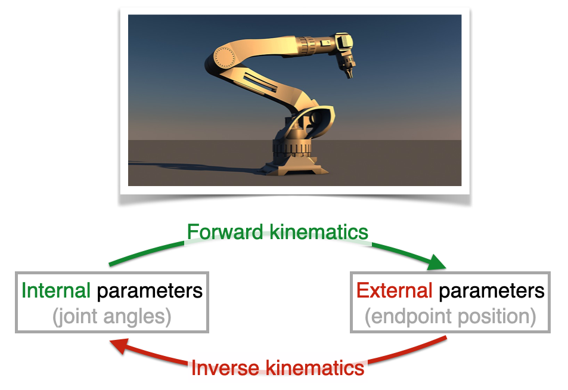

**Figure 1**. Overview of the relation between forward and inverse kinematics for a robot manipulator.  
Robot manipulator image reproduced here under the Pixabay License. [Original image source.](https://pixabay.com/illustrations/cybernetics-robot-robot-arm-1869205/)

```python
from IPython.display import HTML

HTML("""
<center>
<video width="600" controls>
  <source src="video/ik.mp4" type="video/mp4">
</video>
<br>
<em><b>Video 1</b>. &nbsp; Example IK control of a kinematic chain. During the first 10 s of this video, the external controller's influence (the green marker's influence) is toggled on and off. For the remainder of the video the controller is dragged in space to demonstrate near-real-time IK. Video screencast produced in <a href="https://www.blender.org">Blender</a>.</em>
</center>
""")
```

[video not shown]

**Video 1**. Example IK control of a kinematic chain. During the first 10 s of this video, the external controller's influence (the green marker's influence) is toggled on and off. For the remainder of the video the controller is dragged in space to demonstrate near-real-time IK. Video screencast produced in [Blender](https://www.blender.org).

### Relevance to human movement:

- In most human movement experiments, it is not possible to directly measure joint angles.
  - Direct measurement of joint angle would require sensors to be implanted directly in the joints and/or bones.
  - Sensor implantation is possible in some cases (e.g. amputee joints and artificial joints).
  - In other cases sensor implanation is usually not considered ethical.
    - The physical trauma and risks of surgery generally outweigh the benefits of increased measurement accuracy.
    - This is especially true given that IK can be quite accurate.
- It is relatively easy to attach markers to moving body parts and to record marker motion.
  - Based on that marker motion, researchers use IK to calculate joint motion.

# Why are IK calculations difficult?

Back to Table of Contents

- IK calculations are much more difficult than FK calculations, even for simple kinematic chains.
- To explain why, let's first consider a two-link planar kinematic chain (Fig.2).
  - For a given endpoint position C, there are two IK solutions.
  - How does one know which solution is correct?
  - If B represents a joint like the elbow, then only one of these solutions is anatomically possible.
  - If both solutions are anatomically feasible:
    - If the IK goal is marker-based estimation of joint angle, markers must be attached to positions other than A and C.
    - If the IK goal is to move the kinematic chain from a different endpoint C' (not shown in Fig.2) to the given endpoint C (as in robotic manipulators), usually the closest solution is chosen, where "closest" means the smallest change from the current posture.
- This is a simple, 2D kinematic chain, but already IK considerations are complex!

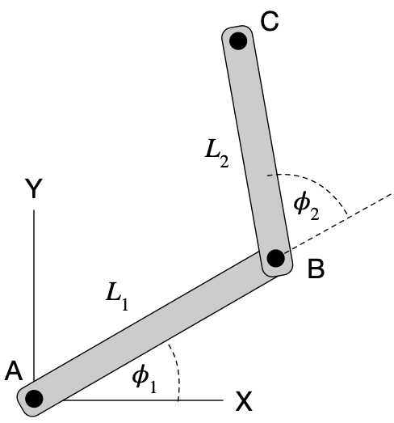

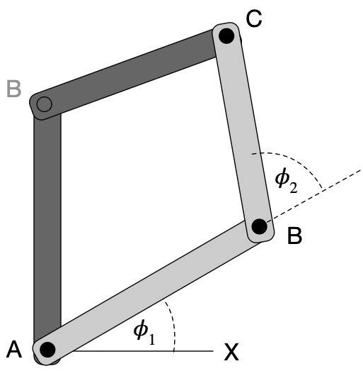

**Figure 2** (Top) Two-link kinematic chain. (Bottom) Two different solutions to the IK problem.

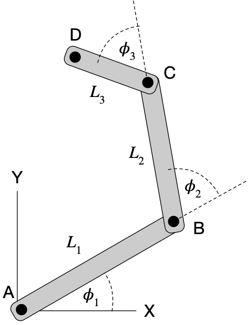

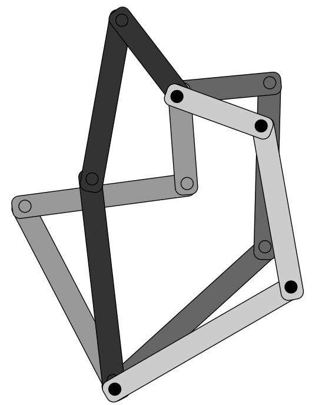

**Figure 3** (Top) Three-link kinematic chain. (Bottom) Infinite solutions to the IK problem.

# IK solution for two-link kinematic chain

Back to Table of Contents

where ($x_C$, $y_C$) is the location of point C, $L$ is segment length and $\phi$ is joint angle (see Fig.2).

- This solution is relatively easy to calculate using geometric principles.
- However, the final IK solution is very difficult to understand!
- Here are two screencasts that describe the solution in greater detail:
  - [Inverse Kinematics for a 2-Joint Robot Arm @ robotacademy.net](https://robotacademy.net.au/lesson/inverse-kinematics-for-a-2-joint-robot-arm-using-geometry/)
  - [Two Link Inverse Kinematics using Jupyter](https://www.youtube.com/watch?v=V4s4Vd2BLi4)
- IK solutions become considerably more complex when there are more links and/or when the joints allow 3D motion.

# Uses of IK in human movement studies

Back to Table of Contents

- The main use of IK in human movement research is: marker-based calculation of joint kinematics using motion capture systems
  - Hundreds of experiments like this are conducted each day around the world.
  - Marker-based IK is often used to calculate 3D angles for 10 or more joints in one measurement.
- IK is also used in optimization research
  - For example: calculating the joint kinematics required to achieve optimum performance (e.g. fastest baseball pitch); in this case the IK goal refers to endpoint velocity, and not necessarily position. These calculations are even more difficult!
- IK is also used in orthopaedic research
  - For example: calculating the artificial joint characteristics necessary to achieve specific kinematics.
- Many different software packages exist for calculating IK. Two common software packages are:
  - [OpenSim](https://simtk.org/projects/opensim)
  - [Visual3D](http://www.yubnub.org/parser/parse?command=g%20cmotion%20visual3d)
- IK calculation remains an active area of research; new and improved IK techniques are regularly introduced

# Summary

Back to Table of Contents

- Inverse kinematics (IK) refers to the process of calculating internal coordinates given external coordinates.
- For human movement studies, IK is regularly used to calculate joint angles based on external marker positions.
- IK is much more complex than forward kinematics (FK) because there are generally an infinite number of solutions that satisfy a specific IK problem.
- IK solutions are quite complex even for a two-link 2D kinematic chains!
- IK research remains active in both human movement research and robotics research.